# Temperature Analysis

R download climate data from ECCC

Need data from 2016-2024 for Twillingate AUT (Station ID = 7083, Climate ID = 8404025), hourly/daily/monthly data available note: Twillingate station (a separate station from Twilingate AUT) is not in use (was in the 1960s)

To gather the publicly available weather data

```r
library(weathercan)
stations_dl()
```

[output not shown]

```r
twillingate <- weather_dl(station_ids = 7083, start = "2016-01-01", end = "2025-06-15")
```

```
As of weathercan v0.3.0 time display is either local time or UTC
See Details under ?weather_dl for more information.
This message is shown once per session
```

```r
#write.csv(twillingate, "twillingate_weather.csv")
```

## Gamm Analysis

Fitting a gamm to this data to investigate changes between years. Focus on 2023/2024 calving season where we observed abnormal antler growth timing.

```r
# Load the dataset (Ensure the file path is correct)
calving_season_data <- read.csv("twillingate_weather.csv")

# Ensure date columns are properly formatted
calving_season_data$date <- as.Date(with(calving_season_data, paste(year, month, day, sep="-")), "%Y-%m-%d")

# Assign calving season variable
calving_season_data$calving_season <- ifelse(calving_season_data$month >= 11,
                                             paste(calving_season_data$year, calving_season_data$year + 1, sep="/"),
                                             paste(calving_season_data$year - 1, calving_season_data$year, sep="/"))

# Convert calving season to a factor and set 2022/2023 as the reference level
calving_season_data$calving_season <- factor(calving_season_data$calving_season,
                                             levels = c("2024/2025", sort(unique(calving_season_data$calving_season[calving_season_data$calving_season != "2024/2025"]), decreasing = T)))

# Filter for relevant months (Nov–May)
calving_season_data <- subset(calving_season_data, month %in% c(11, 12, 1, 2, 3, 4, 5))

# Aggregate data to daily values with mean, min, and max temperature
calving_season_daily <- calving_season_data %>%
  group_by(date, calving_season) %>%
  summarise(mean_temp = mean(temp, na.rm = TRUE),
            min_temp = min(temp, na.rm = TRUE),
            max_temp = max(temp, na.rm = TRUE),
            precip_amt = sum(precip_amt, na.rm = TRUE),
            .groups = 'drop') %>%
  filter(!calving_season %in% c("2015/2016")) #remove incomplete seasons

# Create day of season variable
calving_season_daily <- calving_season_daily %>%
  group_by(calving_season) %>%
  arrange(date) %>%
  mutate(day_of_season = row_number()) %>%
  ungroup()

#create a trimmed dataset for a more targetted model
calving_season_daily_trim <- calving_season_daily %>%
  mutate(month = format(date, "%m")) %>%
  filter(month %in% c("02","03","04"))

# Create day of season variable
calving_season_daily_trim <- calving_season_daily_trim %>%
  group_by(calving_season) %>%
  arrange(date) %>%
  mutate(day_of_season = row_number()) %>% #now 1 is February 1st
  ungroup()
```

### Gamm for Winter months (November to end of May)

Fit a gamm model with an interaction between year (calving_season) and time throughout the winter (day_of_season, count of days starting nov 1 to may 31)

```r
# Fit a Generalized Additive Mixed Model (GAMM) with AR(1) autocorrelation within calving season
gam_model <- gamm(mean_temp ~ s(day_of_season, by=calving_season) + calving_season,
                  data = calving_season_daily,
                  family = gaussian(),
                  correlation = corAR1(form = ~ day_of_season | calving_season),
                  method = "REML")

# Summary of the model
summary(gam_model$gam)
```

```
Family: gaussian
Link function: identity

Formula:
mean_temp ~ s(day_of_season, by = calving_season) + calving_season

Parametric coefficients:
                        Estimate Std. Error t value Pr(>|t|)
(Intercept)             -0.18559    0.40104  -0.463 0.643591
calving_season2023/2024  0.09668    0.56655   0.171 0.864515
calving_season2022/2023 -0.97214    0.69714  -1.394 0.163347
calving_season2021/2022 -0.27274    0.56716  -0.481 0.630660
calving_season2020/2021  0.53558    0.56715   0.944 0.345123
calving_season2019/2020 -1.23018    0.56658  -2.171 0.030043 *
calving_season2018/2019 -2.15936    0.56716  -3.807 0.000145 ***
calving_season2017/2018 -0.77374    0.56716  -1.364 0.172659
calving_season2016/2017 -1.81368    0.56716  -3.198 0.001408 **
---
Signif. codes:  0 ‘***’ 0.001 ‘**’ 0.01 ‘*’ 0.05 ‘.’ 0.1 ‘ ’ 1

Approximate significance of smooth terms:
                                           edf Ref.df     F p-value
s(day_of_season):calving_season2024/2025 3.952  3.952 16.97  <2e-16 ***
s(day_of_season):calving_season2023/2024 3.568  3.568 13.96  <2e-16 ***
s(day_of_season):calving_season2022/2023 3.887  3.887 19.81  <2e-16 ***
s(day_of_season):calving_season2021/2022 4.077  4.077 25.48  <2e-16 ***
s(day_of_season):calving_season2020/2021 3.780  3.780 17.55  <2e-16 ***
s(day_of_season):calving_season2019/2020 4.129  4.129 27.81  <2e-16 ***
s(day_of_season):calving_season2018/2019 4.176  4.176 17.53  <2e-16 ***
s(day_of_season):calving_season2017/2018 3.863  3.863 16.70  <2e-16 ***
s(day_of_season):calving_season2016/2017 3.854  3.854 17.07  <2e-16 ***
---
Signif. codes:  0 ‘***’ 0.001 ‘**’ 0.01 ‘*’ 0.05 ‘.’ 0.1 ‘ ’ 1

R-sq.(adj) =  0.556
  Scale est. = 11.017    n = 1855
```

#### Gamm visualizations

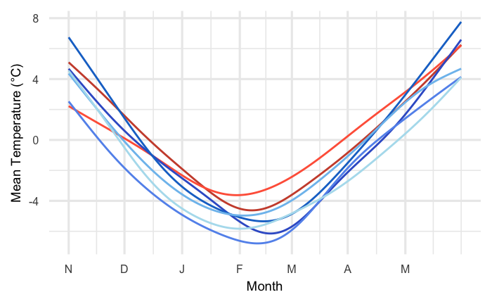

```r
save_as_docx(table_s2, path = "plots/table_s2.docx")
```

[output not shown]

### Narrower date window (Feb to end of April)

Day of season has been changed to a count that starts February 1st.

```r
# Fit a Generalized Additive Mixed Model (GAMM) with AR(1) autocorrelation within calving season
gam_model_trim <- gamm(mean_temp ~ s(day_of_season, by=calving_season) + calving_season,
                  data = calving_season_daily_trim,
                  family = gaussian(),
                  correlation = corAR1(form = ~ day_of_season | calving_season),
                  method = "REML")

# Summary of the model
summary(gam_model_trim$gam)
```

```
Family: gaussian
Link function: identity

Formula:
mean_temp ~ s(day_of_season, by = calving_season) + calving_season

Parametric coefficients:
                        Estimate Std. Error t value Pr(>|t|)
(Intercept)              -0.5807     0.6612  -0.878 0.380155
calving_season2022/2023  -3.2113     0.9376  -3.425 0.000651 ***
calving_season2021/2022  -2.1051     0.9376  -2.245 0.025074 *
calving_season2020/2021  -0.7368     0.9381  -0.785 0.432443
calving_season2019/2020  -2.5617     0.9351  -2.739 0.006314 **
calving_season2018/2019  -3.2295     0.9376  -3.444 0.000607 ***
calving_season2017/2018  -1.5451     0.9378  -1.648 0.099897 .
calving_season2016/2017  -3.0347     0.9376  -3.237 0.001267 **
---
Signif. codes:  0 ‘***’ 0.001 ‘**’ 0.01 ‘*’ 0.05 ‘.’ 0.1 ‘ ’ 1

Approximate significance of smooth terms:
                                           edf Ref.df      F  p-value
s(day_of_season):calving_season2023/2024 1.000  1.000 12.419 0.000453 ***
s(day_of_season):calving_season2022/2023 1.000  1.000 22.326 3.48e-06 ***
s(day_of_season):calving_season2021/2022 1.001  1.001 18.187 2.33e-05 ***
s(day_of_season):calving_season2020/2021 2.087  2.087  8.718 0.000133 ***
s(day_of_season):calving_season2019/2020 1.003  1.003 18.696 1.75e-05 ***
s(day_of_season):calving_season2018/2019 1.000  1.000 29.549 2.39e-07 ***
s(day_of_season):calving_season2017/2018 1.348  1.348 10.663 0.000287 ***
s(day_of_season):calving_season2016/2017 1.000  1.000 13.018 0.000330 ***
---
Signif. codes:  0 ‘***’ 0.001 ‘**’ 0.01 ‘*’ 0.05 ‘.’ 0.1 ‘ ’ 1

R-sq.(adj) =  0.465
  Scale est. = 10.969    n = 714
```

#### Visualizations of trimmed gamm.

The abnormal year is almost linear over this time period. I’m not sure we want to use this at all but now it exists.

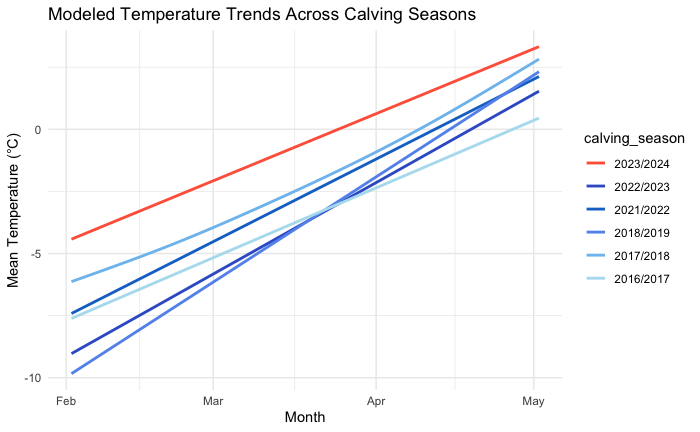

```r
table_s3 <- as_flextable(gam_model_trim$gam)
save_as_docx(table_s3, path = "../plots/table_s3.docx")
```